# Lab 10 - Trees, Bagging, Random Forest

```r
knitr::opts_chunk$set(eval = F, include  = T)
```

# Learning goals

- Perform classification and regression with tree-based methods in R
- Recognize that tree-based methods are capable of capturing non-linearities by splitting multiple times on the same variables
- Compare the performance of classification trees, bagging,and random forests for predicting heart disease based on the `heart` data.

# Lab description

For this lab we will be working with simulated data and the `heart` dataset that you can download from [here](https://github.com/JSC370/jsc370-2022/blob/main/data/heart/heart.csv)

### Setup packages

You should install and load `rpart` (trees), `randomForest` (random forest), `gbm` (gradient boosting) and `xgboost` (extreme gradient boosting).

```r
install.packages(c("rpart", "randomForest","gbm","xgboost"))
```

```r
install.packages("rpart.plot")
```

### Load packages and data

```r
library(tidyverse)
library(rpart)
library(rpart.plot)
library(randomForest)
library(gbm)
library(xgboost)
library(kableExtra)
library(ggplot2)
library(dplyr)

heart<-read.csv("https://raw.githubusercontent.com/jeffreyz374/JSC370-Labs-And-Assignments/main/data/heart.csv")

head(heart)
```

```
##   Age Sex    ChestPain RestBP Chol Fbs RestECG MaxHR ExAng Oldpeak Slope Ca
## 1  63   1      typical    145  233   1       2   150     0     2.3     3  0
## 2  67   1 asymptomatic    160  286   0       2   108     1     1.5     2  3
## 3  67   1 asymptomatic    120  229   0       2   129     1     2.6     2  2
## 4  37   1   nonanginal    130  250   0       0   187     0     3.5     3  0
## 5  41   0   nontypical    130  204   0       2   172     0     1.4     1  0
## 6  56   1   nontypical    120  236   0       0   178     0     0.8     1  0
##         Thal AHD
## 1      fixed  No
## 2     normal Yes
## 3 reversable Yes
## 4     normal  No
## 5     normal  No
## 6     normal  No
```

## Question 1: Trees with simulated data

- Simulate data from a random uniform distribution [-5,5] and normally distributed errors (s.d = 0.5)
- Create a non-linear relationship y=sin(x)+error
- Split the data into test and training sets (500 points each), plot the data

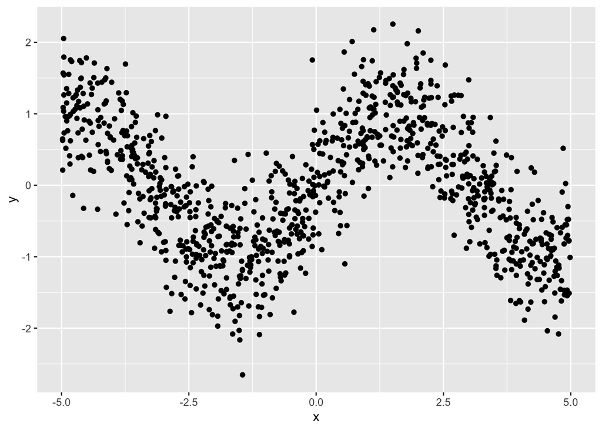

```r
set.seed(1984)
n <- 1000
x <- runif(n, -5, 5)
error <- rnorm(n, sd = 0.5)
y <- sin(x) + error
nonlin <- data.frame(y = y, x = x)

train_size <- sample(1:1000, size = 500)
nonlin_train <- nonlin[train_size,]
nonlin_test <- nonlin[-train_size,]

nonlin %>%
  ggplot(aes(y = y, x = x)) +
  geom_point()
```

- Fit a regression tree using the training set, plot it

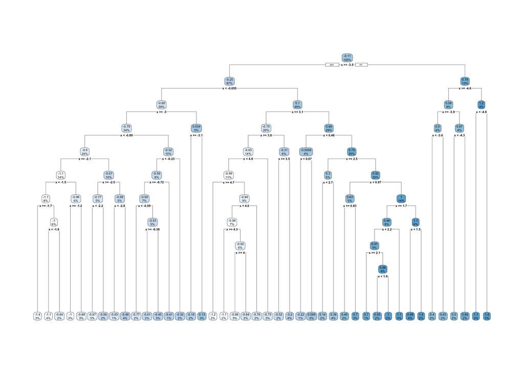

```r
treefit <- rpart(y ~ x, method = "anova", control = list(cp = 0), data = nonlin_train)

rpart.plot(treefit)
```

- Determine the optimal complexity parameter (cp) to prune the tree

```r
printcp(treefit)
```

```
##
## Regression tree:
## rpart(formula = y ~ x, data = nonlin_train, method = "anova",
##     control = list(cp = 0))
##
## Variables actually used in tree construction:
## [1] x
##
## Root node error: 419.01/500 = 0.83803
##
## n= 500
##
##            CP nsplit rel error  xerror     xstd
## 1  0.19469747      0   1.00000 1.00402 0.050219
## 2  0.03406113      3   0.41591 0.45381 0.026383
```

[output cut: 32 more lines]

```r
optimalcp <- 0.00227267
```

- Prune and plot the tree and summarize

```r
treepruned <- prune(treefit, cp = optimalcp)
summary(treepruned)
```

```
## Call:
## rpart(formula = y ~ x, data = nonlin_train, method = "anova",
##     control = list(cp = 0))
##   n= 500
##
##             CP nsplit rel error    xerror       xstd
## 1  0.194697471      0 1.0000000 1.0040153 0.05021945
## 2  0.034061135      3 0.4159076 0.4538104 0.02638272
## 3  0.027393414      4 0.3818465 0.4005153 0.02381225
## 4  0.018916616      5 0.3544530 0.3935674 0.02372447
## 5  0.018741339      6 0.3355364 0.3960865 0.02397866
## 6  0.012132319      7 0.3167951 0.3733062 0.02312415
## 7  0.011774257      8 0.3046628 0.3603378 0.02145075
## 8  0.010680660      9 0.2928885 0.3578205 0.02147093
## 9  0.007302594     10 0.2822078 0.3534446 0.02167188
## 10 0.002272670     11 0.2749053 0.3370788 0.02130490
##
## Variable importance
##   x
## 100
##
## Node number 1: 500 observations,    complexity param=0.1946975
##   mean=-0.1147421, MSE=0.8380283
##   left son=2 (436 obs) right son=3 (64 obs)
##   Primary splits:
##       x < -3.484362   to the right, improve=0.1407386, (0 missing)
##
## Node number 2: 436 observations,    complexity param=0.1946975
##   mean=-0.2463199, MSE=0.7852125
##   left son=4 (193 obs) right son=5 (243 obs)
##   Primary splits:
##       x < -0.05508361 to the left,  improve=0.1965717, (0 missing)
##
## Node number 3: 64 observations,    complexity param=0.01213232
##   mean=0.781632, MSE=0.2764066
##   left son=6 (43 obs) right son=7 (21 obs)
##   Primary splits:
##       x < -4.612867   to the right, improve=0.2873718, (0 missing)
##
## Node number 4: 193 observations,    complexity param=0.03406113
```

[output cut: 67 more lines]

```
##
## Node number 46: 26 observations
##   mean=0.3027775, MSE=0.233719
##
## Node number 47: 98 observations,    complexity param=0.007302594
##   mean=0.9238571, MSE=0.2530437
##   left son=94 (26 obs) right son=95 (72 obs)
##   Primary splits:
##       x < 0.9713606   to the left,  improve=0.1233912, (0 missing)
##
## Node number 94: 26 observations
##   mean=0.6298082, MSE=0.2488088
##
## Node number 95: 72 observations
##   mean=1.030041, MSE=0.2120744
```

- Based on the plot and/or summary of the pruned tree create a vector of the (ordered) split points for variable x, and a vector of fitted values for the intervals determined by the split points of x.

```r
x_splits <- sort(treepruned$splits[, 'index'])
y_splits <- treepruned$frame[which(treepruned$frame[, 'var'] == '<leaf>'), 'yval']
```

- plot the step function corresponding to the fitted (pruned) tree

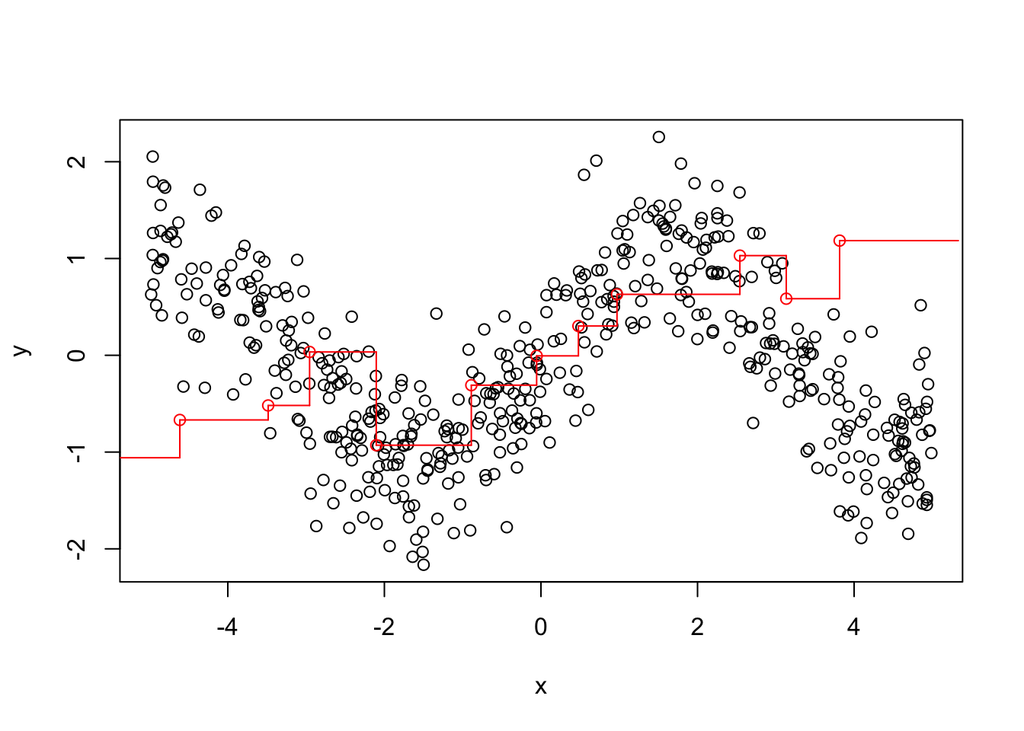

```r
plot(y ~ x, data = nonlin_train)
plot(stepfun(x_splits, y_splits), add = TRUE, col = 'red')
```

- Fit a linear model to the training data and plot the regression line.
- Contrast the quality of the fit of the tree model vs. linear regression by inspection of the plot
- Compute the test MSE of the pruned tree and the linear regression model

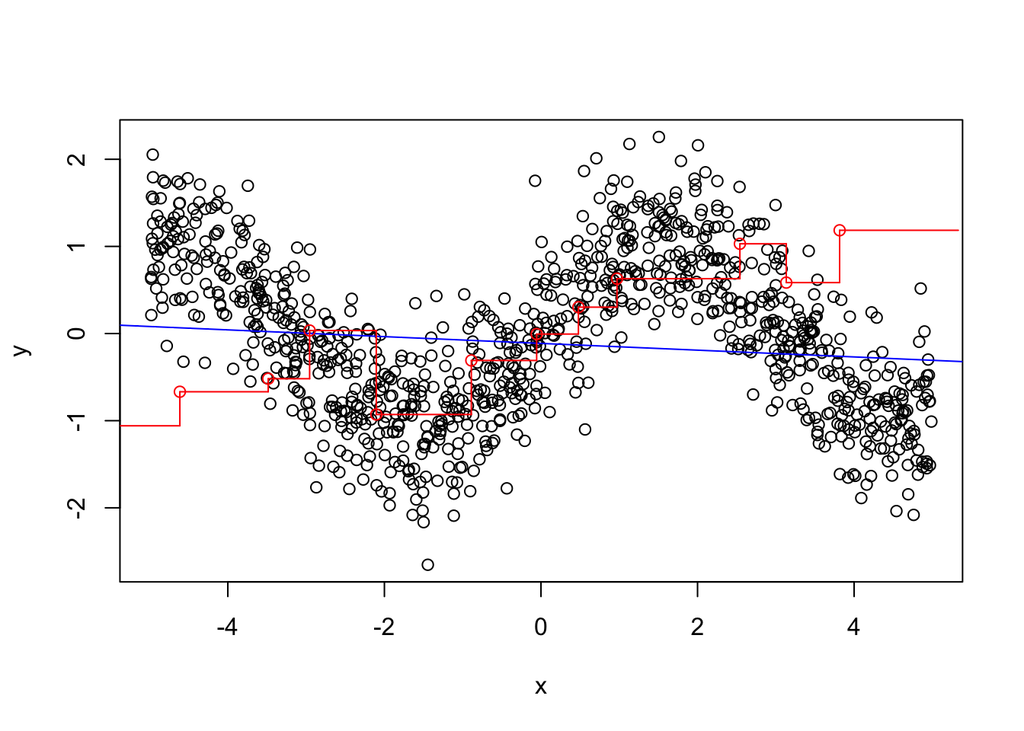

```r
lmfit <- lm(y ~ x, data = nonlin_train)

plot(y ~ x)
abline(lmfit, col = "blue")
plot(stepfun(x_splits, y_splits), add = TRUE, col = "red")
```

```r
tree_pred <- predict(treepruned, nonlin_test)
nonlin_test_tree <- cbind(nonlin_test, tree_pred)

tree_mse <- sum((nonlin_test_tree$tree_pred - nonlin_test_tree$y)^2) / dim(nonlin_test_tree)[1]
tree_mse
```

```
## [1] 0.3230568
```

```r
lm_pred <- predict(lmfit, nonlin_test)
nonlin_test_lm <- cbind(nonlin_test, lm_pred)
lm_mse <- sum((nonlin_test_lm$lm_pred - nonlin_test_lm$y)^2) / 500
lm_mse
```

```
## [1] 0.7847042
```

- Is the lm or regression tree better at fitting a non-linear function?

From the above plot, we can see that the regression tree is a much better fit for fitting this non-linear function.

## Question 2: Analysis of Real Data

- Split the `heart` data into training and testing (70-30%)

```r
set.seed(1234)
train_idx <- sample(1:nrow(heart), round(0.7 * nrow(heart)))
train <- heart[train_idx,]
test <- heart[-train_idx,]
```

- Fit a classification tree using rpart, plot the full tree

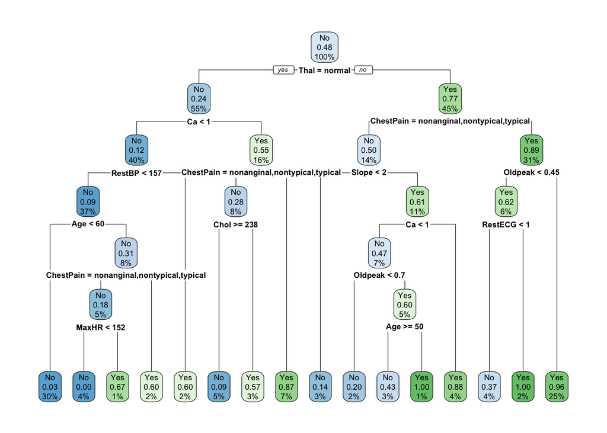

```r
heart_tree <- rpart(AHD~., data = train, method = "class", control = list(minsplit = 10), minbucket = 3, cp = 0, xval = 10)

rpart.plot(heart_tree)
```

- Plot the complexity parameter table for an rpart fit and prune the tree

```r
printcp(heart_tree)
```

```
##
## Classification tree:
## rpart(formula = AHD ~ ., data = train, method = "class", control = list(minsplit = 10),
##     minbucket = 3, cp = 0, xval = 10)
##
## Variables actually used in tree construction:
##  [1] Age       Ca        ChestPain Chol      MaxHR     Oldpeak   RestBP
##  [8] RestECG   Slope     Thal
##
## Root node error: 101/212 = 0.47642
##
## n= 212
##
##          CP nsplit rel error  xerror     xstd
## 1 0.5049505      0   1.00000 1.00000 0.072000
## 2 0.0544554      1   0.49505 0.55446 0.063558
## 3 0.0247525      3   0.38614 0.48515 0.060772
## 4 0.0148515      5   0.33663 0.55446 0.063558
## 5 0.0099010      7   0.30693 0.51485 0.062026
## 6 0.0066007     12   0.25743 0.53465 0.062811
## 7 0.0000000     15   0.23762 0.53465 0.062811
```

```r
optimalcp <- heart_tree$cptable[which.min(heart_tree$cptable[,"xerror"]), "CP"]
```

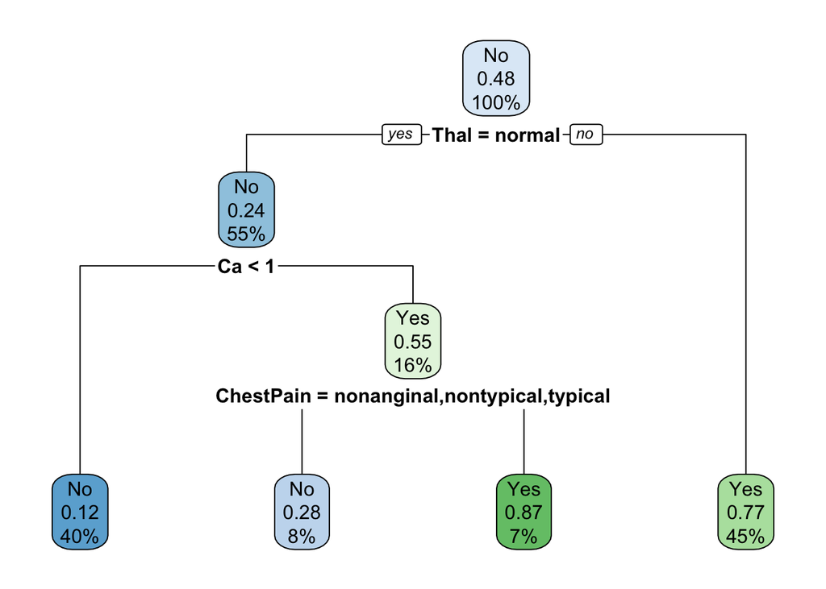

```r
heart_tree_prune <- prune(heart_tree, cp = optimalcp)

rpart.plot(heart_tree_prune)
```

- Compute the test misclassification error

```r
heart_pred <- predict(heart_tree_prune, test)
heart_pred <- as.data.frame(heart_pred)
heart_pred$AHD <- ifelse(heart_pred$Yes > 0.5, "yes", "no")

confmatrix_table <- table(true = test$AHD, predicted = heart_pred$AHD)
confmatrix_table
```

```
##      predicted
## true  no yes
##   No  39  14
##   Yes  6  32
```

```r
misclass_err <- (confmatrix_table[1, 2] + confmatrix_table[2, 1]) / nrow(test)
misclass_err
```

```
## [1] 0.2197802
```

- Fit the tree with the optimal complexity parameter to the full data (training + testing)

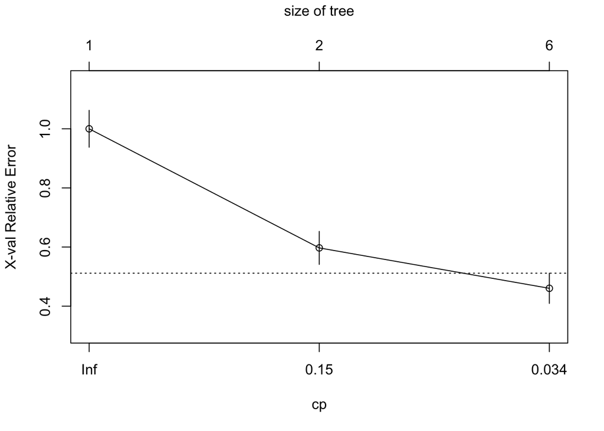

```r
heart_tree <- rpart(AHD~., data = heart, method = "class", control = list(cp = optimalcp))
plotcp(heart_tree)
```

- Out of Bag (OOB) error for tree

```r
min(heart_tree$cptable[,'xerror']) * nrow(heart)
```

```
## [1] 139.5108
```

## Question 3: Bagging, Random Forest

- Use the training and testing sets from above. Train each of the models on the training data and extract the cross-validation (or out-of-bag error for bagging and Random forest).
- For bagging use `randomForest` with `mtry` equal to the number of features (all other parameters at their default values). Generate the variable importance plot using `varImpPlot` and extract variable importance from the `randomForest` fitted object using the `importance` function.

```r
heart_bag <- randomForest(as.factor(AHD)~., data = train, mtry = 13, na.action = na.omit)
sum(heart_bag$err.rate[,1])
```

```
## [1] 119.1527
```

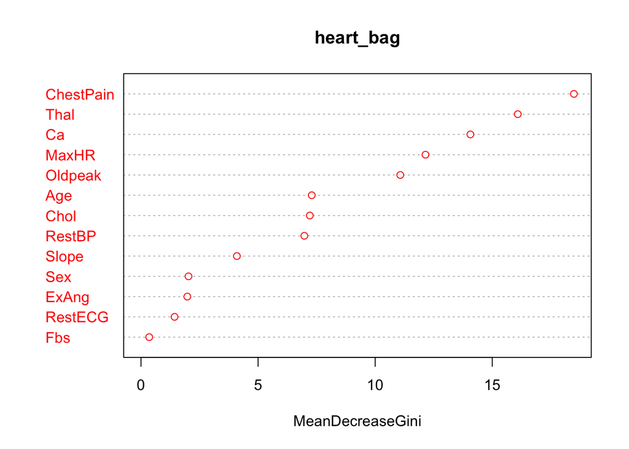

```r
varImpPlot(heart_bag, n.var = 13, col = "red")
```

```r
importance(heart_bag)
```

```
##           MeanDecreaseGini
## Age              7.2930159
## Sex              2.0290282
## ChestPain       18.4886629
## RestBP           6.9754269
## Chol             7.2093123
## Fbs              0.3513432
## RestECG          1.4337686
## MaxHR           12.1494964
## ExAng            1.9774185
## Oldpeak         11.0726738
## Slope            4.0948161
## Ca              14.0674606
## Thal            16.0908650
```

- For random forests use `randomForest` with the default parameters. Generate the variable importance plot using `varImpPlot` and extract variable importance from the `randomForest` fitted object using the `importance` function.

```r
heart_rf <- randomForest(as.factor(AHD)~., data = train, na.action = na.omit)

sum(heart_rf$err.rate[,1])
```

```
## [1] 111.6495
```

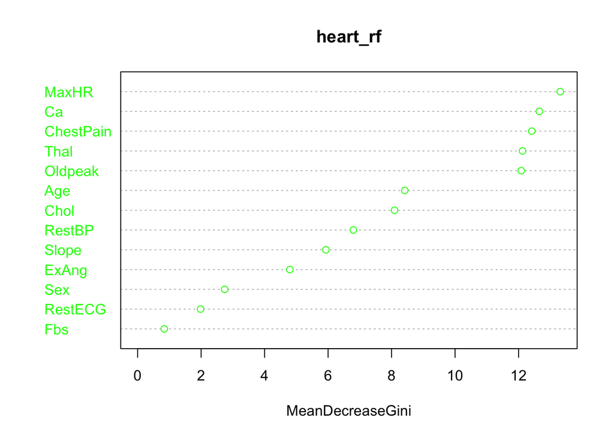

```r
varImpPlot(heart_rf, n.var = 13, col = "green")
```

```r
importance(heart_rf)
```

```
##           MeanDecreaseGini
## Age              8.4153940
## Sex              2.7423400
## ChestPain       12.4168620
## RestBP           6.7937383
## Chol             8.0919173
## Fbs              0.8396021
## RestECG          1.9820545
## MaxHR           13.3130687
## ExAng            4.7956684
## Oldpeak         12.0837949
## Slope            5.9311566
## Ca              12.6549891
## Thal            12.1249560
```

# Deliverables

1. Questions 1-4 answered, pdf or html output uploaded to quercus